# Parking in Eindhoven, Data Analysis & Investigation

The city of Eindhoven has tons of available data. This is mostly comprised of geographic point locations combined with various other domains. This data by itself can provide some interesting insights into the city and its surroundings.

What is even more interesting that new 'hidden' information is uncovered when combining some of these domains.

In the upcoming sections the parking data will be analyzed, treated and displayed. The dataset contains the following:

- ID - Id of the object
- STREET - Street name
- TYPE - Type of parking spot (6 unique)
- COUNT - Number of available parking spots
- LON - Longitudinal coordinates
- LAT - Latitudal coordinates
- GEO_2D - Geolocation in 2D

The goal is to analyze the data and describe what steps are needed to succesfully recreate a scatter plot of parking spots from the city of Eindhoven.

Next to that a look will be taken at a different approach of importing data. (not csv dump but web api)

And finally ready the prepared dataset with a storage solution that can be used for ML algorithms.

## Importing the dataset

Firstly the dataset and standard libraries which are used frequently have to be imported.

De delimiter of the dataset is';' in this situation. This can be seen by opening the dataset.

The top datapoint from the dataset has been removed because it contained column information

```python
import pandas as pd
import numpy as np

column_names = ['ID', 'STREET', 'TYPE', 'COUNT', 'LON', 'LAT', 'GEO_2D']
dataset = pd.read_csv("/Users/Matt/Desktop/AI/PersonalNotebooks/DAIA/Eindhoven Data/Ehvn_parking.csv",
                      delimiter=';', names=column_names)
#dataset['ID'] = np.sort(dataset['ID'], 0)
dataset = dataset.iloc[1:, :]
dataset.head()
```

|  | ID | STREET | TYPE | COUNT | LON | LAT | GEO_2D |
| --- | --- | --- | --- | --- | --- | --- | --- |
| 1 | 5869 | Winkelcentrum Woensel | Parkeerplaats | 1 | 5,473875387 | 51,46894486 | 51,4689448625;5,47387538744 |
| 2 | 5873 | Winkelcentrum Woensel | Parkeerplaats | 1 | 5,472963547 | 51,46882236 | 51,4688223571;5,47296354721 |
| 3 | 5874 | Winkelcentrum Woensel | Parkeerplaats | 1 | 5,472994225 | 51,4688196 | 51,468819602;5,4729942254 |
| 4 | 5875 | Winkelcentrum Woensel | Parkeerplaats | 1 | 5,473027096 | 51,46881958 | 51,4688195778;5,47302709629 |
| 5 | 5876 | Winkelcentrum Woensel | Parkeerplaats | 1 | 5,47306434 | 51,46881818 | 51,468818175;5,47306433969 |

By printing the shape of the dataset we can see that it contains 11337 items.

```python
dataset.shape
```

```
(11337, 7)
```

## Compostion of the dataset

To get a more specific look into the composition of the dataset we call the describe function.

With this we can see the spread of data.

```python
dataset.describe()
```

|  | ID | STREET | TYPE | COUNT | LON | LAT | GEO_2D |
| --- | --- | --- | --- | --- | --- | --- | --- |
| count | 11337 | 11337 | 11337 | 11337 | 11337 | 11337 | 11337 |
| unique | 11337 | 175 | 6 | 1 | 11312 | 11293 | 11314 |
| top | 10627 | Winkelcentrum Woensel | Parkeerplaats | 1 | 5,477768367 | 51,44720477 | 51,4459196436;5,45682777173 |
| freq | 1 | 1904 | 10260 | 11337 | 2 | 2 | 2 |

From the table above we can see that:

1. There are 175 unique street adresses
2. There are 6 types of parking spot
3. Each datapoint is 1 parking spot

Checking for null values is another important step. These can have a negative impact on the accuracy of the model. Also we could run into some difficulties when performing mutations.

```python
dataset.isnull().sum()
```

```
ID        0
STREET    0
TYPE      0
COUNT     0
LON       0
LAT       0
GEO_2D    0
dtype: int64
```

Luckily there are no null values.

But this does not mean that the data meets all standards. Lets take a closer look.

## Treating the dataset

From the composition of the dataset we deduced there are 175 different streets, and over 11k parking spots. It would be a difficult task to plot all 11k points.

We will take each street as a single point, and the weight will be dependent on the count of parking spots in that street.

Lets see the count of each street.

```python
dataset['STREET'].value_counts()
```

```
Winkelcentrum Woensel            1904
Niet ingevuld                     731
Bomanshof                         295
Veldmaarschalk Montgomerylaan     281
Professor Dr Dorgelolaan          248
                                 ...
Korte Havenstraat                   3
Benedictusstraat                    3
Burgemeester Vogelspad              2
Boschdijk                           1
Molenveld                           1
Name: STREET, Length: 175, dtype: int64
```

We can see that there is one street which is a little suspicious. 'Niet ingevuld' means that this field has not been filled in.

These datapoints will be removed from the dataset for now. Later on they will be plotted individually with a different color of representation compared to the streets.

```python
unknown_street_parking = [d for d in dataset['STREET'] if d == 'Niet ingevuld']

#pandas.Dateframe.isin will return boolean values depending on whether
#each element is inside the list a or not. You then invert this with
#the ~ to convert True to False and vice versa.
dataset = dataset[~dataset['STREET'].isin(unknown_street_parking)]

street_count = dataset['STREET'].value_counts()
street_count.head()
```

```
Winkelcentrum Woensel            1904
Bomanshof                         295
Veldmaarschalk Montgomerylaan     281
Professor Dr Dorgelolaan          248
Woenselse Markt                   239
Name: STREET, dtype: int64
```

Now that we have the parking count of each street. we can apply this later to the coordinates of each street.

To calculate the mean coordinates of each street the dataset will be grouped and a mean will be determined.

By opening the dataset in Excel I noticed that the structure was a little off. So lets check the type of LON and LAT, If we want to perform calculations on these they should be either a float or int.

```python
type(dataset['LON'][1])
```

```
str
```

The type of LON and LAT is a string. It has to be converted to a float first. Also the decimal has to be replaced by a point.

```python
dataset['LON'] = dataset['LON'].str.replace(',', '.').astype(float)
dataset['LAT'] = dataset['LAT'].str.replace(',', '.').astype(float)
dataset.head()
```

|  | ID | STREET | TYPE | COUNT | LON | LAT | GEO_2D |
| --- | --- | --- | --- | --- | --- | --- | --- |
| 1 | 5869 | Winkelcentrum Woensel | Parkeerplaats | 1 | 5.473875 | 51.468945 | 51,4689448625;5,47387538744 |
| 2 | 5873 | Winkelcentrum Woensel | Parkeerplaats | 1 | 5.472964 | 51.468822 | 51,4688223571;5,47296354721 |
| 3 | 5874 | Winkelcentrum Woensel | Parkeerplaats | 1 | 5.472994 | 51.468820 | 51,468819602;5,4729942254 |
| 4 | 5875 | Winkelcentrum Woensel | Parkeerplaats | 1 | 5.473027 | 51.468820 | 51,4688195778;5,47302709629 |
| 5 | 5876 | Winkelcentrum Woensel | Parkeerplaats | 1 | 5.473064 | 51.468818 | 51,468818175;5,47306433969 |

The rest will be dropped from the table. And a mean will be calculated for both the LON and LAT coordinates.

```python
combo_arr = dataset.drop(['TYPE', 'COUNT', 'GEO_2D', 'ID'], axis=1)

grouped_combo = combo_arr.groupby(['STREET']).mean()
grouped_combo['pointCount'] = street_count
grouped_combo
```

| STREET | LON | LAT | pointCount |
| --- | --- | --- | --- |
| Aalsterweg | 5.486350 | 51.426629 | 89 |
| Acaciastraat | 5.455077 | 51.444660 | 37 |
| Adriaan Mulderweg | 5.396767 | 51.453249 | 52 |
| Aert Roelofsstraat | 5.486266 | 51.438990 | 5 |
| Akkerstraat | 5.474520 | 51.432661 | 39 |
| ... | ... | ... | ... |
| Wouter Hollemanplein | 5.463745 | 51.438419 | 41 |
| Zanddreef | 5.407306 | 51.446949 | 29 |
| Zwaanstraat | 5.451118 | 51.448693 | 19 |
| Zwembadweg | 5.477882 | 51.434027 | 16 |
| van Meursstraat | 5.475043 | 51.429263 | 70 |

174 rows × 3 columns

Finally with the dataset we have created a graph can be plotted. Because the data is scattered across several areas of concentraion, the 'scatter plot' will be used.

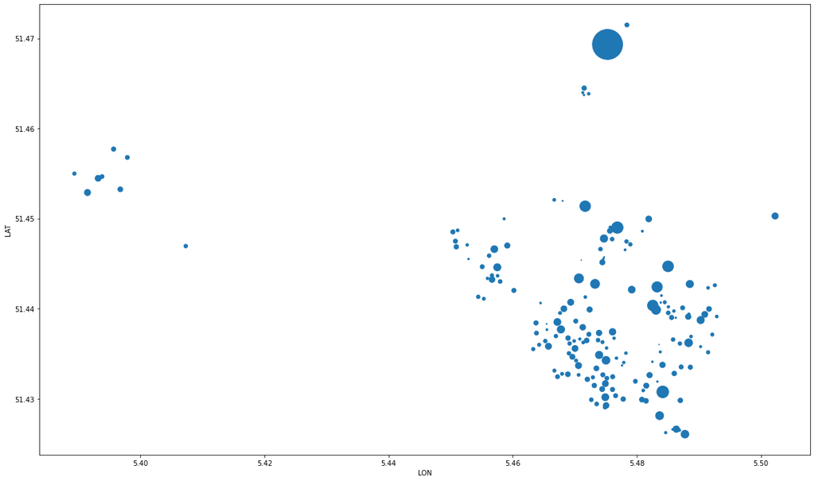

```python
grouped_combo.plot(x='LON', y='LAT', s='pointCount', kind='scatter',
                   colormap="hot_r", figsize=[20, 12])
```

For a final representation the data will be exported so that it can be used in external software.

```python
grouped_combo.to_csv(r'/Users/Matt/Desktop/grouped_parking_dataset.csv', index = False)
combo_arr.to_csv(r'/Users/Matt/Desktop/all_parking_dataset.csv', index = False)
```

### Results

#### Grouped Parking

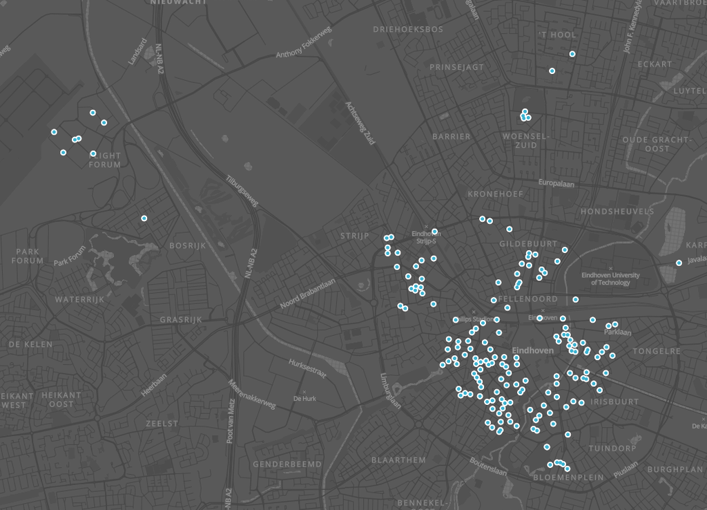

#### Individual Parking

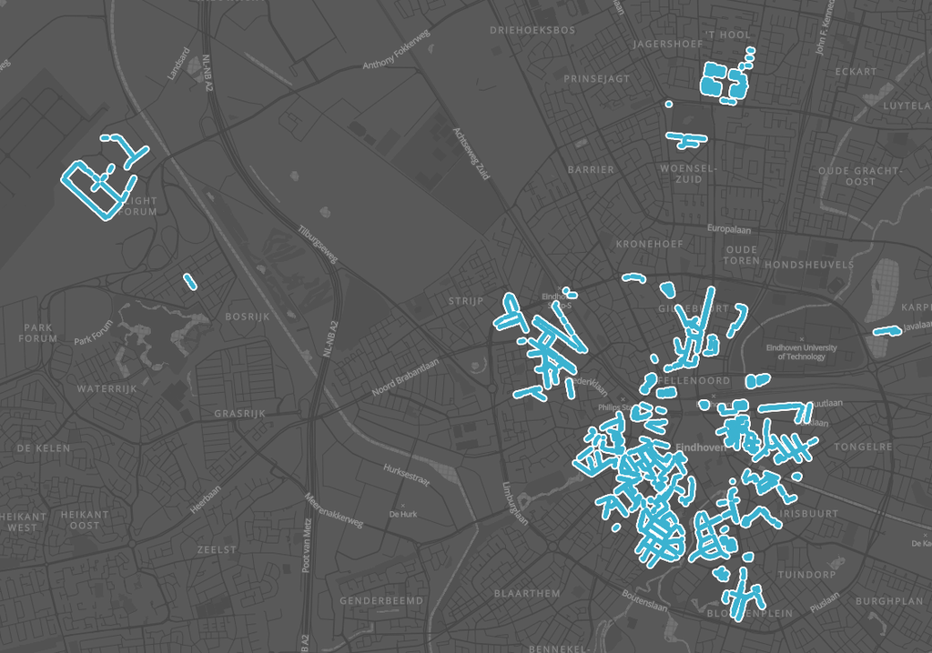

### Conclusion

As we can see from the images above data representation plays a very important role. It has to be correct, but it also has to be displayed in an understandable manner.

By only displaying the scatter plot you get a rough idea of where the hot-spots are located. But you cannot place it very well because there is no location to correlate to through sight.

By implementing a map things become more clear. The only problem was that I could not figure out how to apply concentration on the points. This is deceiving because it looks like all points are equal.

When displaying the final map with all points from the original dataset we can see the actual concentration. Which differs from both the scatter plot and grouped plots on the map.

By creating different angles of approach to a certain situation the total picture renders clearer. Story-telling plays an important role in data analysis.

## Dataset from web api

An import from an external website is an api call with a specific route.

### Importing packages

The panda package has already been imported. To make an HTTP request we need another package:

```python
import requests
```

This package will help us communicate between the local browser and web server.

### GET request from endpoint

The next will be making the GET request to the endpoint. To do this we will need a target URL.

```python
#url = 'https://data.eindhoven.nl/api/records/1.0/search/?dataset=meldingen-openbare-ruimte&q=&rows=10000&refine.onderwerp=7.1+Parkeeroverlast'
#url = 'https://data.eindhoven.nl/api/records/1.0/search/?dataset=meldingen-openbare-ruimte&q=&rows=10000&sort=aangemaakt&facet=nummer&facet=gebied&facet=onderwerp&facet=aangemaakt&facet=gewijzigd&facet=buurt&facet=locatie_ter_hoogte_van&facet=wijkcode&facet=stadsdeelcode_&facet=wijknaam&facet=stadsdeelnaam'
url = 'https://data.eindhoven.nl/api/records/1.0/search/?dataset=parkeerplaatsen&q=&rows=1000&facet=straat&facet=type_en_merk&facet=aantal'
```

We will use the requests library to make a GET request

```python
r = requests.get(url)
r
```

```
<Response [200]>
```

A status code 200 means that the requests has been succesful!

### Extracting data

Now the data will be extracted using the Json method.

```python
json = r.json()
```

### Exploring the dataset

It is important to skim through the data first and find a way to convert it into a dataframe.

The keys() method returns a view object. The view object contains the keys of the dictionary, as a list.

```python
json.keys()
```

```
dict_keys(['nhits', 'parameters', 'records', 'facet_groups'])
```

lets explore the keys

```python
json['nhits']
```

```
11337
```

```python
#json['records']
```

```python
#json['facet_groups']
```

```python
json['parameters']
```

```
{'dataset': 'parkeerplaatsen',
 'timezone': 'UTC',
 'rows': 1000,
 'start': 0,
 'format': 'json',
 'facet': ['straat', 'type_en_merk', 'aantal']}
```

We can also check the type to check if the data can be used

```python
type(json['nhits'])
```

```
int
```

```python
type(json['records'])
```

```
list
```

```python
type(json['facet_groups'])
```

```
list
```

```python
type(json['parameters'])
```

```
dict
```

records can be something interesting. Lets see what the list is comprised of.

```python
type(json['records'][1])
```

```
dict
```

A list of dictionaries! This can be used to create a dataframe.

### Creating a dataframe

```python
api_records_df = pd.DataFrame(json['records'])
api_records_df.head()
```

|  | datasetid | recordid | fields | geometry | record_timestamp |
| --- | --- | --- | --- | --- | --- |
| 0 | parkeerplaatsen | 50553d1ffdcf54a093cc5564ab1980917afece65 | {'straat': 'Jan Smitzlaan', 'type_en_merk': 'P... | {'type': 'Point', 'coordinates': [5.4824676316... | 2021-09-01T21:45:05.888000+00:00 |
| 1 | parkeerplaatsen | 7e8afd66ac528f2030b70a16836f1a645928f224 | {'straat': 'Elzentlaan', 'type_en_merk': 'Park... | {'type': 'Point', 'coordinates': [5.4806874060... | 2021-09-01T21:45:05.888000+00:00 |
| 2 | parkeerplaatsen | d742871e8801904c68ee82b3e115ff52bd8b657c | {'straat': 'Tesselschadelaan', 'type_en_merk':... | {'type': 'Point', 'coordinates': [5.4832232439... | 2021-09-01T21:45:05.888000+00:00 |
| 3 | parkeerplaatsen | 21b9e4b4b5b1edfdc05e1664afdc69c0d485503e | {'straat': 'Tesselschadelaan', 'type_en_merk':... | {'type': 'Point', 'coordinates': [5.4834061845... | 2021-09-01T21:45:05.888000+00:00 |
| 4 | parkeerplaatsen | 27491cfd4e0ef482f05573dce5f4937dc9d8f9dd | {'straat': 'Hertog Hendrik van Brabantplein', ... | {'type': 'Point', 'coordinates': [5.4860747806... | 2021-09-01T21:45:05.888000+00:00 |

```python
api_records_df['geometry'][1]
```

```
{'type': 'Point', 'coordinates': [5.48068740606, 51.4325385563]}
```

```python
api_records_df['fields'][1]
```

```
{'straat': 'Elzentlaan',
 'type_en_merk': 'Parkeerplaats Afgekruist',
 'objectid': 2837,
 'geo_point_2d': [51.4325385563, 5.48068740606],
 'geo_shape': {'type': 'Point',
  'coordinates': [5.480687406056828, 51.43253855631658]},
 'aantal': 1.0}
```

Here we can see that this is the actual data that is of importance to us. It is a Json saved in a string as a feature in the dataset. Lets make a new dataframe.

```python
df = pd.DataFrame(list(api_records_df['fields']), columns=['objectid', 'type_en_merk', 'straat',
                                               'geo_point_2d', 'geo_shape',
                                               'aantal'])
df.head()
```

|  | objectid | type_en_merk | straat | geo_point_2d | geo_shape | aantal |
| --- | --- | --- | --- | --- | --- | --- |
| 0 | 2836 | Parkeerplaats Gehandicapten | Jan Smitzlaan | [51.432749012, 5.48246763162] | {'type': 'Point', 'coordinates': [5.4824676316... | 1.0 |
| 1 | 2837 | Parkeerplaats Afgekruist | Elzentlaan | [51.4325385563, 5.48068740606] | {'type': 'Point', 'coordinates': [5.4806874060... | 1.0 |
| 2 | 2840 | Parkeerplaats Gehandicapten | Tesselschadelaan | [51.4318574604, 5.48322324391] | {'type': 'Point', 'coordinates': [5.4832232439... | 1.0 |
| 3 | 2842 | Parkeerplaats Gehandicapten | Tesselschadelaan | [51.4319579646, 5.48340618457] | {'type': 'Point', 'coordinates': [5.4834061845... | 1.0 |
| 4 | 2845 | Parkeerplaats | Hertog Hendrik van Brabantplein | [51.4330624689, 5.48607478067] | {'type': 'Point', 'coordinates': [5.4860747806... | 1.0 |

The data is now ready to use for treatment etc. This will not be done now because the goal was to prepare a dataset from an api-endpoint ready for interpretation.

# Conclusion

Treating a dataset so that it can be interpreted and displaying the results in a graph. In addition to that importing a dataset through different means other than a csv dump to get comparable data.

From previous exercises I got some experience in treating and preparing data. I applied the same techniques. I added extra explanations before each code block so that me and the reader are satisfied with the flow and clarity of the notebook. Working with world-map data was a first, as well as importing data through a web-api. I used a lot of sources and translated the information into my own words for better understanding.

One of the most important skills I got to practice with during this exercise is visual story telling using data. It is of great importance to not only treat and clean data. But also to give it a nice representation so that connections or irregularities. can be seen. Secondly I also got to train with importing data from an external web-api. In theory I would be able to make my own API's now and import them for further analysis.

The only difference I would make is to markdown my though process. Even when trying out new pieces of code. In my opinion the code was tried out, but didnt succeed should be left there with an explanation as to why it did not live up to the standards. In this way the thoughtprocess is even more established in the notebook.